# DATA-413/613 Homework 06: Web Scraping

Author

Te-Jou Hou (Carol)

# 1 IMDB List of Best Foreign Films

Use {tidyverse} and {rvest} packages in solving this problem.

```r
library(tidyverse)
library(rvest)
```

IMDB has a list of the [Top 100 Best Foreign Films](https://www.imdb.com/list/ls062615147/). For each movie, we want to get the following data (where it exists) on the webpage into a tibble.

- Number, Title, Year, Length, Rating, Star Rating, Votes, Metascore, Plot Summary, Director, Stars, and Country
1. Use the included historical file imdb_html.html instead of downloading a new file.

```r
imdb_html_obj <- read_html("../analysis/imdb_html.html")
```

2. The CSS Selector for the “movie” element is `".ipc-metadata-list .ipc-metadata-list-summary-item"`.
1. Use it to scrape all the data for each movie at once.
   - Save the result with the name `movie_data`. You should get a list with 25 elements, one for each movie.
   - Show the length of the list.

   ```r
   movie_data <- html_elements(imdb_html_obj,
                   css = ".ipc-metadata-list .ipc-metadata-list-summary-item")
   length(movie_data)
   ```

   ```
   [1] 25
   ```

2. Insert a screen shot of the Developer tools showing the Inspected element. It should look something like this (but will vary with your browser and the date of your screen shot).

[figure not shown]

3. Create a function called `get_text` with an argument for CSS values. The function should use the just-created `movie_data` list and return the text associated with the elements of interest. The function’s steps should start with the `movie-data` object, pipe to a function to scrape the elements based on the input CSS argument, and extract the text from those elements as a character vector.

```r
get_text <- function(css_values) {
  movie_data |>
    html_elements(css = css_values) |>
    html_text2()
}
```

4. We will use `get_text()` as part of a strategy to scrape the elements of interest from `movie_data.`
- The new DOM combines some formerly distinct elements into groups and eliminates their separate CSS selectors.
- It is also true that not every element exists for a movie. Because the DOM uses generic classes for the list elements in some groups, it is not straightforward to figure out which scraped data goes with which movie. As an example, there are 25 movies but only 18 metascores.
- However, we can scrape at the grouped class level and then figure out which data belongs where during cleaning.
- We will scrape both the groups and the individual elements in cases where some elements in the group have their own class as it will simplify cleaning.

We are interested in the following CSS selectors

- “.ipc-title__text”, # number and title
- “.dli-title-metadata”, # year, Run Time, Rating
- “.ipc-rating-star–rating”, # IMDB stars rating
- “.ipc-rating-star–voteCount”, # votes”
- “.kcRAsW”, # stars-votes-metascore group
- ” .dli-plot-container .ipc-html-content-inner-div”, # plot summary
- “.Cxrmk”, # plot-directors-star group
- “.brndVc .ipc-html-content-inner-div” # Country
1. Create a vector called `my_vars` with a variable name for each of the elements of interest.

```r
my_vars <- c("number_title", "year_run_rating", "Star_Rating", "Votes", "stars_votes_metascore", "Plot", "plot_directors_stars", "Country")
```

2. Create a vector called `my_css` with the corresponding CSS selector for each element of interest.
   - Be sure to put them in the correct order so they align to the order of the `my_vars` variable names.

   ```r
   my_css <- c(".ipc-title__text", ".dli-title-metadata", ".ipc-rating-star--rating", ".ipc-rating-star--voteCount", ".kcRAsW", " .dli-plot-container .ipc-html-content-inner-div", ".Cxrmk", ".brndVc .ipc-html-content-inner-div"
   )
   ```

3. Use `map2()` with `my_vars` and `my_css` to scrape each element of interest and combine into a single a data frame called `movies_df`.
- Consider a strategy like the following that requires very few lines of code.
  - Create an anonymous function with two arguments: one for the element name and one for the css.
  - The function should first scrape the element using your function and the css argument.
  - It should transform that vector into a tibble using `tibble()` while using the `.name_repair=` argument with the “purrR” anonymous function operator `~` for the vector of names.
  - Once all the elements are scraped, you should have a list of length 8 where each element is a single-variable data frame with 25 rows.
  - You have scraped the data of interest and ready to tidy it.
  - Use a {purrr} `list_*` function to transform the `map2()` list output into a single data frame by binding the columns together.
- Hint: as a build-and-test strategy, solve in steps working “inside-out”: - Make sure your `get_text()` scrape function works with a `css` argument. - Put it inside `tibble()` with the `.names_repair =` argument for the variable names. - Convert to an anonymous function with two arguments and test with single-value arguments. - Put inside `map2()` with the vectors you created in part b. - Pipe to a `purrr::list_*()` function to combine into a single data frame and save as `movies_df`.

```r
map2(my_vars, my_css,
     ~ {data <- get_text(.y)
       tibble(data, .name_repair = ~ .x)})|>
  purrr::list_cbind()|>
  set_names(my_vars)->
  movies_df
```

4. Use `glimpse()` to check your data frame is tidy with 8 columns and 25 rows. It should look like the following:

```r
glimpse(movies_df)
```

```
Rows: 25
Columns: 8
$ number_title          <chr> "1. City of God", "2. A Short Film About Love", …
$ year_run_rating       <chr> "20022h 10mR", "19881h 27mNot Rated", "20001h 54…
$ Star_Rating           <chr> "8.6", "8.1", "7.5", "8.1", "7.6", "8.1", "7.1",…
$ Votes                 <chr> " ( 809K )", " ( 26K )", " ( 196K )", " ( 219K )…
$ stars_votes_metascore <chr> "8.6 (809K)Rate\n79Metascore", "8.1 (26K)Rate", …
$ Plot                  <chr> "In the slums of Rio, two kids' paths diverge as…
$ plot_directors_stars  <chr> "In the slums of Rio, two kids' paths diverge as…
$ Country               <chr> "From Brazil", "From Poland", "From Japan", "Fro…
```

5. Clean the data.
1. Fix `number-title`. Use a {tidyr} to separate `number_title` by a delimiter into two columns called `Rank` and `Title`. Convert `Rank` to a number. Save the `movies_df` data frame and glimpse it.

```r
movies_df |>
  separate(number_title, into = c("Rank", "Title"), sep = "\\. ", convert = TRUE)|>
  mutate(Rank = as.numeric(Rank))->
  movies_df
glimpse(movies_df)
```

```
Rows: 25
Columns: 9
$ Rank                  <dbl> 1, 2, 3, 4, 5, 6, 7, 8, 9, 10, 11, 12, 13, 14, 1…
$ Title                 <chr> "City of God", "A Short Film About Love", "Battl…
$ year_run_rating       <chr> "20022h 10mR", "19881h 27mNot Rated", "20001h 54…
$ Star_Rating           <chr> "8.6", "8.1", "7.5", "8.1", "7.6", "8.1", "7.1",…
$ Votes                 <chr> " ( 809K )", " ( 26K )", " ( 196K )", " ( 219K )…
$ stars_votes_metascore <chr> "8.6 (809K)Rate\n79Metascore", "8.1 (26K)Rate", …
$ Plot                  <chr> "In the slums of Rio, two kids' paths diverge as…
$ plot_directors_stars  <chr> "In the slums of Rio, two kids' paths diverge as…
$ Country               <chr> "From Brazil", "From Poland", "From Japan", "Fro…
```

2. Fix `year_run_rating`.
- Use a {tidyr} function to separate `year_run_rating` using regex into two columns called `Year` and `run_rating`. Hint: Getting the year is straight-forward. Consider using the “preceded by” look around to get the rest.
- Convert `Year` to a number.
- Use a {tidyr} function to separate `run_rating` using regex into two columns called `Run_time` and `Rating`. Hint: Look at the data to see a pattern in how all times end. Consider using the “preceded by” look around to get the rest. For any empty values, convert to `NA`.
- Convert Run_time into minutes as a number. Hint: use string_extract with regex and parse_number and add 60* hours and minutes.

Save the `movies_df` data frame and glimpse it.

```r
movies_df |>
  separate(year_run_rating, into = c("Year", "run_rating"),
           sep = "(?=\\d{1}h)")|>
  mutate(Year = as.numeric(Year))|>
  separate(run_rating, into = c("Run_time", "Rating"),
           sep = "(?<=[hm])(?=[A-Z])",
           fill = "right")|>
  mutate(Run_time = case_when(
           str_detect(Run_time, "m") ~
           parse_number(str_extract(Run_time,"\\d+h")) * 60
           +parse_number(str_extract(Run_time, "\\d+m")),
           TRUE ~ parse_number(str_extract(Run_time,"\\d+h")) * 60
         ))->
  movies_df

glimpse(movies_df)
```

```
Rows: 25
Columns: 11
$ Rank                  <dbl> 1, 2, 3, 4, 5, 6, 7, 8, 9, 10, 11, 12, 13, 14, 1…
$ Title                 <chr> "City of God", "A Short Film About Love", "Battl…
$ Year                  <dbl> 2002, 1988, 2000, 2014, 1998, 2016, 2016, 1988, …
$ Run_time              <dbl> 130, 87, 114, 122, 80, 145, 130, 88, 86, 125, 95…
$ Rating                <chr> "R", "Not Rated", "Not Rated", "R", "R", "Not Ra…
$ Star_Rating           <chr> "8.6", "8.1", "7.5", "8.1", "7.6", "8.1", "7.1",…
$ Votes                 <chr> " ( 809K )", " ( 26K )", " ( 196K )", " ( 219K )…
$ stars_votes_metascore <chr> "8.6 (809K)Rate\n79Metascore", "8.1 (26K)Rate", …
$ Plot                  <chr> "In the slums of Rio, two kids' paths diverge as…
$ plot_directors_stars  <chr> "In the slums of Rio, two kids' paths diverge as…
$ Country               <chr> "From Brazil", "From Poland", "From Japan", "Fro…
```

3. Fix Star_Rating, Votes and Metascore.
- Convert `Star_Rating` to a number
- Convert `Votes` to a number.
- Extract metascore and convert to a number that appears after `Votes`.
- Remove `stars_votes_metascroe` from the data frame.
- Save the data frame and glimpse it.

```r
movies_df |>
  mutate(Star_Rating = as.numeric(Star_Rating))|>
  mutate(Metascore = as.numeric(str_extract(stars_votes_metascore,
                                         "(?<=Rate\\s)\\d+")), .after = Votes)|>
  mutate(Votes = as.numeric(str_replace_all(Votes, "[()K]", "")))|>
  select(-stars_votes_metascore)->
  movies_df

glimpse(movies_df)
```

```
Rows: 25
Columns: 11
$ Rank                 <dbl> 1, 2, 3, 4, 5, 6, 7, 8, 9, 10, 11, 12, 13, 14, 15…
$ Title                <chr> "City of God", "A Short Film About Love", "Battle…
$ Year                 <dbl> 2002, 1988, 2000, 2014, 1998, 2016, 2016, 1988, 1…
$ Run_time             <dbl> 130, 87, 114, 122, 80, 145, 130, 88, 86, 125, 95,…
$ Rating               <chr> "R", "Not Rated", "Not Rated", "R", "R", "Not Rat…
$ Star_Rating          <dbl> 8.6, 8.1, 7.5, 8.1, 7.6, 8.1, 7.1, 8.5, 8.1, 8.1,…
$ Votes                <dbl> 809.0, 26.0, 196.0, 219.0, 209.0, 177.0, 72.0, 31…
$ Metascore            <dbl> 79, NA, 81, 77, 79, 85, 89, 94, 87, NA, 89, NA, 7…
$ Plot                 <chr> "In the slums of Rio, two kids' paths diverge as …
$ plot_directors_stars <chr> "In the slums of Rio, two kids' paths diverge as …
$ Country              <chr> "From Brazil", "From Poland", "From Japan", "From…
```

4. Fix Directors and Stars
- Extract just the Directors and Stars from the `plot_directors_stars` (note that they are all preceded by `"Director"`) and put just before `Plot`.
- Separate the new column into two columns called `Directors` and `Stars`.
- Extra Credit: Note the names are not split cleanly. Clean up the character vectors by splitting the string into two or more names as appropriate. Do not worry about if your regex does not catch all the possible diacritical marks, just worry about upper and lower case letters.
- Remove the `plot_directors_stars`.

```r
movies_df |>
  mutate(Directors_Stars = str_extract(plot_directors_stars, "Director.*"), .before = Plot) |>
  mutate(Directors_Stars = str_remove(Directors_Stars, "Director")) |>
  separate(Directors_Stars, into = c("Directors", "Stars"), sep = "Stars", fill = "right")|>
  mutate(Directors = str_replace_all(Directors, "(?<=[a-z])(?=[A-Z])", ", "))|>
  mutate(Stars = str_replace_all(Stars, "(?<=[a-z])(?=[A-Z])", ", "))|>
  mutate(Directors = str_split(Directors, ",\\s*"),
    Stars = str_split(Stars, ",\\s*"))|>
  select(-plot_directors_stars)->
  movies_df

glimpse(movies_df)
```

```
Rows: 25
Columns: 12
$ Rank        <dbl> 1, 2, 3, 4, 5, 6, 7, 8, 9, 10, 11, 12, 13, 14, 15, 16, 17,…
$ Title       <chr> "City of God", "A Short Film About Love", "Battle Royale",…
$ Year        <dbl> 2002, 1988, 2000, 2014, 1998, 2016, 2016, 1988, 1988, 1991…
$ Run_time    <dbl> 130, 87, 114, 122, 80, 145, 130, 88, 86, 125, 95, 118, 104…
$ Rating      <chr> "R", "Not Rated", "Not Rated", "R", "R", "Not Rated", "R",…
$ Star_Rating <dbl> 8.6, 8.1, 7.5, 8.1, 7.6, 8.1, 7.1, 8.5, 8.1, 8.1, 7.3, 7.2…
$ Votes       <dbl> 809.0, 26.0, 196.0, 219.0, 209.0, 177.0, 72.0, 316.0, 387.…
$ Metascore   <dbl> 79, NA, 81, 77, 79, 85, 89, 94, 87, NA, 89, NA, 75, 92, 81…
$ Directors   <list> <"Fernando Meirelles", "Kátia Lund">, "Krzysztof Kieslows…
$ Stars       <list> <"Alexandre Rodrigues", "Leandro Firmino", "Matheus Nacht…
$ Plot        <chr> "In the slums of Rio, two kids' paths diverge as one strug…
$ Country     <chr> "From Brazil", "From Poland", "From Japan", "From Argentin…
```

5. Fix Country
- Remove “From” from the values in `country` and move before `Plot`.

```r
movies_df |>
  mutate(Country = str_remove(Country, "From\\s*"))|>
  relocate(Country, .before = Plot)->
  movies_df

glimpse(movies_df)
```

```
Rows: 25
Columns: 12
$ Rank        <dbl> 1, 2, 3, 4, 5, 6, 7, 8, 9, 10, 11, 12, 13, 14, 15, 16, 17,…
$ Title       <chr> "City of God", "A Short Film About Love", "Battle Royale",…
$ Year        <dbl> 2002, 1988, 2000, 2014, 1998, 2016, 2016, 1988, 1988, 1991…
$ Run_time    <dbl> 130, 87, 114, 122, 80, 145, 130, 88, 86, 125, 95, 118, 104…
$ Rating      <chr> "R", "Not Rated", "Not Rated", "R", "R", "Not Rated", "R",…
$ Star_Rating <dbl> 8.6, 8.1, 7.5, 8.1, 7.6, 8.1, 7.1, 8.5, 8.1, 8.1, 7.3, 7.2…
$ Votes       <dbl> 809.0, 26.0, 196.0, 219.0, 209.0, 177.0, 72.0, 316.0, 387.…
$ Metascore   <dbl> 79, NA, 81, 77, 79, 85, 89, 94, 87, NA, 89, NA, 75, 92, 81…
$ Directors   <list> <"Fernando Meirelles", "Kátia Lund">, "Krzysztof Kieslows…
$ Stars       <list> <"Alexandre Rodrigues", "Leandro Firmino", "Matheus Nacht…
$ Country     <chr> "Brazil", "Poland", "Japan", "Argentina", "Germany", "Sout…
$ Plot        <chr> "In the slums of Rio, two kids' paths diverge as one strug…
```

6. Analyze Stars and Metascore
1. Create a plot of `stars` versus `metascore`, color coded by rating rating (i.e., for predicting stars rating based on meta-critic scores).
   - Include a *single* Ordinary Least Squares smoothing line with no standard errors.
   - Save the object with the name `my_plot`.
   - Display `my_plot`.
   - Interpret the plot to answer if the plot suggests a strong linear association between the two predictors.

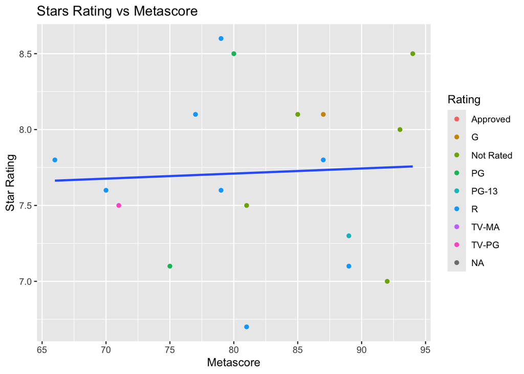

```r
    ggplot(movies_df, aes(x = Metascore, y = Star_Rating)) +
      geom_point(aes(color = Rating)) +
      geom_smooth(method = "lm", se = FALSE) +
      labs(x = "Metascore", y = "Star Rating", title = "Stars Rating vs Metascore")->
      my_plot
    my_plot
```

```
The scatter plot shows a relatively dispersed distribution of points with no obvious trend, and the Ordinary Least Squares smoothing line is also close to horizontal. Therefore, the linear association between `Metascore` and `Star_Rating` is likely not strong.
```

2. Use the linear model function `lm()` to quantitatively assess if there is there a meaningful relationship.
   - Show the summary of the output and interpret it in terms of the model $p$-value and the adjusted R-Squared.

```r
linear_model <- lm(Star_Rating ~ Metascore, data = movies_df)
summary(linear_model)
```

```
Call:
lm(formula = Star_Rating ~ Metascore, data = movies_df)

Residuals:
     Min       1Q   Median       3Q      Max
-1.01351 -0.38358 -0.00514  0.37144  0.89318

Coefficients:
            Estimate Std. Error t value Pr(>|t|)
(Intercept) 7.442548   1.380450   5.391    6e-05 ***
Metascore   0.003345   0.016767   0.200    0.844
---
Signif. codes:  0 '***' 0.001 '**' 0.01 '*' 0.05 '.' 0.1 ' ' 1

Residual standard error: 0.5664 on 16 degrees of freedom
  (7 observations deleted due to missingness)
Multiple R-squared:  0.002482,  Adjusted R-squared:  -0.05986
F-statistic: 0.0398 on 1 and 16 DF,  p-value: 0.8444
```

The analysis results show a *p-value* of 0.844. Thus, we would fail to reject the null hypothesis, suggesting that `Metascore` does not have a meaningful impact on `Star_Rating`. Additionally, the *adjusted R-squared* value of -0.05986 implies that the model fits worse than a simple mean model, indicating that Metascore fails to explain the variability in Star_Rating effectively.

3. Add the default non-linear smoother with color “red” to `my_plot` and comment on the new plot.

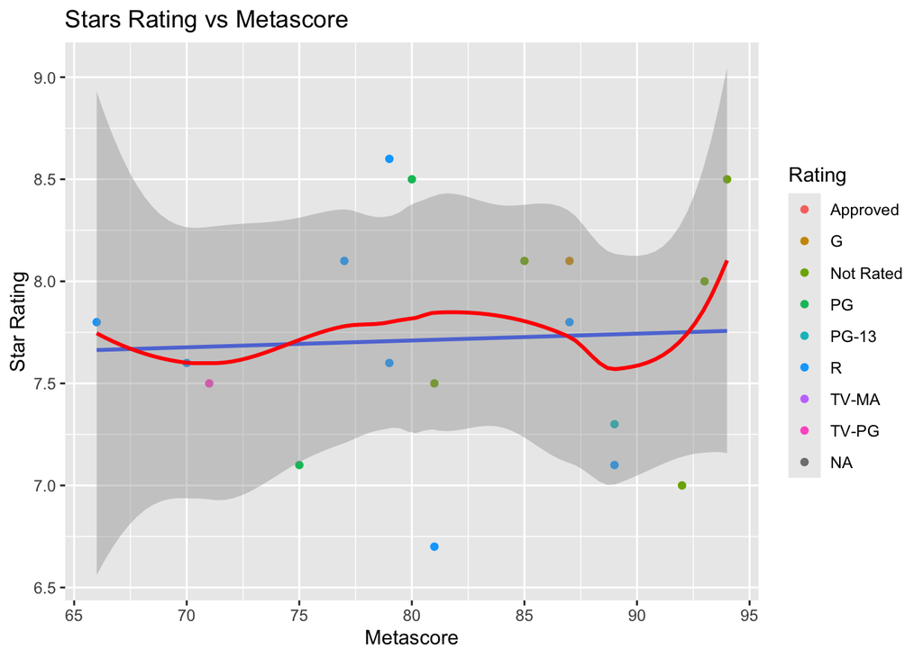

```r
my_plot + geom_smooth(color = "red")
```

From the plot, it can be seen that the non-linear smoother line only fluctuates slightly up and down near the Ordinary Least Squares smoothing line (which is almost horizontal). Therefore, this further confirms that the association between Metascore and Star Rating is likely not strong.

7. Votes vs Year
1. Create a combined scatter plot and a violin plot of votes by year, both color-coded by rating, and add a single linear smoother.

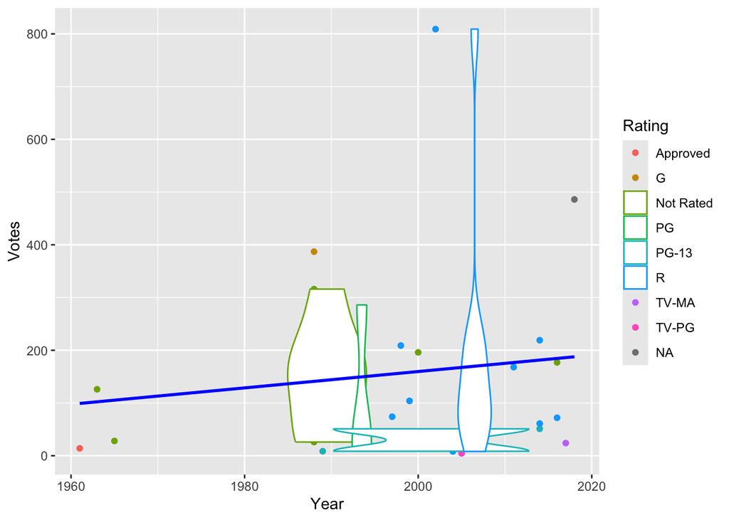

```r
ggplot(movies_df, aes(x = Year, y = Votes, color = Rating)) +
  geom_point() +
  geom_violin() +
  geom_smooth(method = "lm", se = FALSE, color = "blue")
```

2. Interpret the plot.

3. Explain why the example plot legend has squares with no dots and what you could do to fix it.

R draws plots based on the order specified in our code. Since we first create the scatter plot, then overlay the violin plot, and finally add the regression line, the points for the “squares” in the legend are obscured by the violin plot, resulting in the legend displaying “with no dots.” We can resolve this issue by changing the code to draw the violin plot first and then the scatter plot.

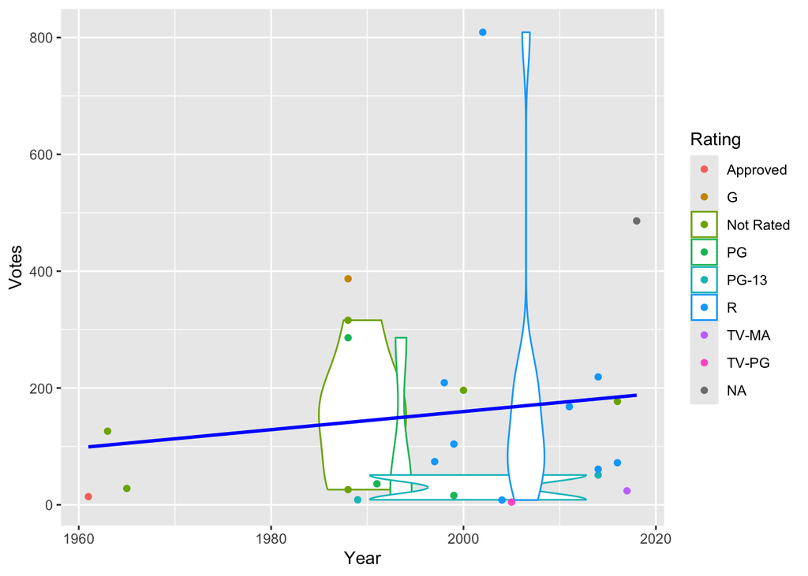

```r
ggplot(movies_df, aes(x = Year, y = Votes, color = Rating)) +
  geom_violin() +
  geom_point() +
  geom_smooth(method = "lm", se = FALSE, color = "blue")
```

4. Run a linear model of `Votes` as the response variable and `Year` as the predictor variable and interpret the results.

```r
model <- lm(Votes ~ Year, data = movies_df)
summary(model)
```

```
Call:
lm(formula = Votes ~ Year, data = movies_df)

Residuals:
    Min      1Q  Median      3Q     Max
-162.83 -120.39  -77.36   37.61  646.23

Coefficients:
             Estimate Std. Error t value Pr(>|t|)
(Intercept) -2943.625   4656.522  -0.632    0.534
Year            1.552      2.331   0.666    0.512

Residual standard error: 190.3 on 23 degrees of freedom
Multiple R-squared:  0.01891,   Adjusted R-squared:  -0.02375
F-statistic: 0.4432 on 1 and 23 DF,  p-value: 0.5122
```

The *p-value* is 0.512, which is greater than 0.05 suggests that we fail to reject the null hypothesis, which in this context means there is insufficient evidence to conclude that the year has a meaningful impact on the number of votes. Furthermore, the negative *adjusted R-squared* value indicates that the model does not effectively explain the variability in vote counts.

8. Reproduce the following plot (in the HTML) as closely as possible and interpret the plot.

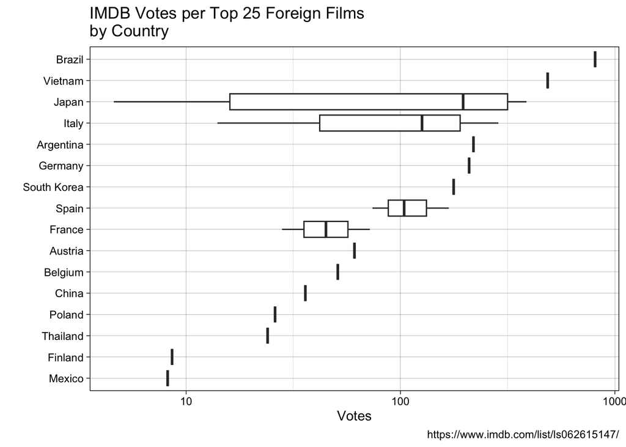

```r
movies_df |>
  group_by(Country) |>
  summarize(MaxVotes = max(Votes, na.rm = TRUE)) |>
  arrange(MaxVotes)|>
  pull(Country)->
  country_order

movies_df |>
  mutate(Country = factor(Country, levels = country_order)) ->
  movies_df

ggplot(movies_df, aes(x = Country, y = Votes)) +
  geom_boxplot() +
  scale_y_log10() +
  labs(title = "IMDB Votes per Top 25 Foreign Films\nby Country",
       x = "",
       y = "Votes",
       caption = "https://www.imdb.com/list/ls062615147/") +
  theme_linedraw() +
  coord_flip()
```

9. Extra Credit: Get data for all 100 movies
- Refer to Notes: [Scraping Dynamic Web Pages with the {RSelenium} Package](https://rressler.quarto.pub/data-413-613/07_getting_data_web_scraping_main.html#scraping-dynamic-web-pages-with-the-rselenium-package)
1. Use the following code to establish an R Selenium session using a Firefox browser. Be sure you have followed the notes to have the latest versions of the browser and its drivers.

```r
my_cssr <- c(
  ".dli-parent .ipc-title__text",
  ".dli-title-metadata",
  ".ipc-rating-star--rating",
  ".ipc-rating-star--voteCount",
  ".lfvcNT",
  ".dli-plot-container .ipc-html-content-inner-div",
  ".fwUPUj",
  ".cgTbSv"
)

library(RSelenium)

driver <- rsDriver(browser = "firefox", verbose = FALSE)
remote_driver <- driver$client
server <- driver$server


remote_driver$navigate("https://www.imdb.com/list/ls062615147/")

for (i in 1:5) {
  remote_driver$executeScript("window.scrollTo(0, document.body.scrollHeight);")
  Sys.sleep(0.1)  # wait for 0.1 seconds
}

movies100 <- map(my_cssr, function(css) {
  elements <- remote_driver$findElements(using = "css selector", value = css)
  texts <- map(elements, function(x) x$getElementText())
})

remote_driver$close()
server$stop()
rm(driver, remote_driver, server, i)
```

# 2 Pick Your Own Site to Scrape.

Select any site from which you wish to scrape data that is not one we discussed in class. You can use one of the sites below if it is of interest.

1. Download the page.

```r
wiki_html_obj <- read_html("https://en.wikipedia.org/wiki/Statistical_area_(United_States)")
```

2. Save the page as an html_object to the `data_raw` folder.

```r
xml2::write_html(wiki_html_obj, "../data_raw/Statistical_Areas_of_the _United States.html")
```

3. Identify and scrape the elements of interest.

[figure not shown]

```r
wiki_elements <- html_elements(wiki_html_obj,
                css = ".wikitable")
```

4. Convert to a data frame, tidy, and clean the data.

```r
wiki_text <- html_text2(wiki_elements)
sub("^.*?MSAs\tμSAs", "", wiki_text)|>
  strsplit("\n")->
  wiki_text

tibble(text = unlist(wiki_text))|>
  separate(text, into = c("Jurisdiction", "Delineated areas", "CSAs", "Core-based areas", "MSAs", "μSAs"), sep = "\t", fill = "right")|>
  slice(-c(1, 53, 55))|>
  mutate(Jurisdiction = str_replace(Jurisdiction, "\\[2\\]", ""))|>
  mutate(Jurisdiction = str_replace(Jurisdiction, "\\[3\\]", ""))|>
  mutate(
    `Delineated areas` = as.numeric(`Delineated areas`),
    CSAs = as.numeric(CSAs),
    `Core-based areas` = as.numeric(`Core-based areas`),
    MSAs = as.numeric(MSAs),
    `μSAs` = as.numeric(`μSAs`)
  )->
  wiki_df

glimpse(wiki_df)
```

```
Rows: 52
Columns: 6
$ Jurisdiction       <chr> "Alabama", "Alaska", "Arizona", "Arkansas", "Califo…
$ `Delineated areas` <dbl> 35, 4, 13, 25, 42, 20, 9, 4, 35, 46, 4, 22, 47, 50,…
$ CSAs               <dbl> 9, 0, 2, 4, 7, 3, 2, 1, 7, 7, 0, 5, 14, 10, 7, 3, 8…
$ `Core-based areas` <dbl> 26, 4, 11, 21, 35, 17, 7, 3, 28, 39, 4, 17, 33, 40,…
$ MSAs               <dbl> 13, 2, 7, 7, 25, 7, 5, 2, 22, 15, 2, 7, 12, 15, 9, …
$ μSAs               <dbl> 13, 2, 4, 14, 10, 10, 2, 1, 6, 24, 2, 10, 21, 25, 1…
```

5. Pose a question and create a plot to provide an answer.

How does the number of combined statistical areas (CSAs) relate to the number of Core-based areas across different states?

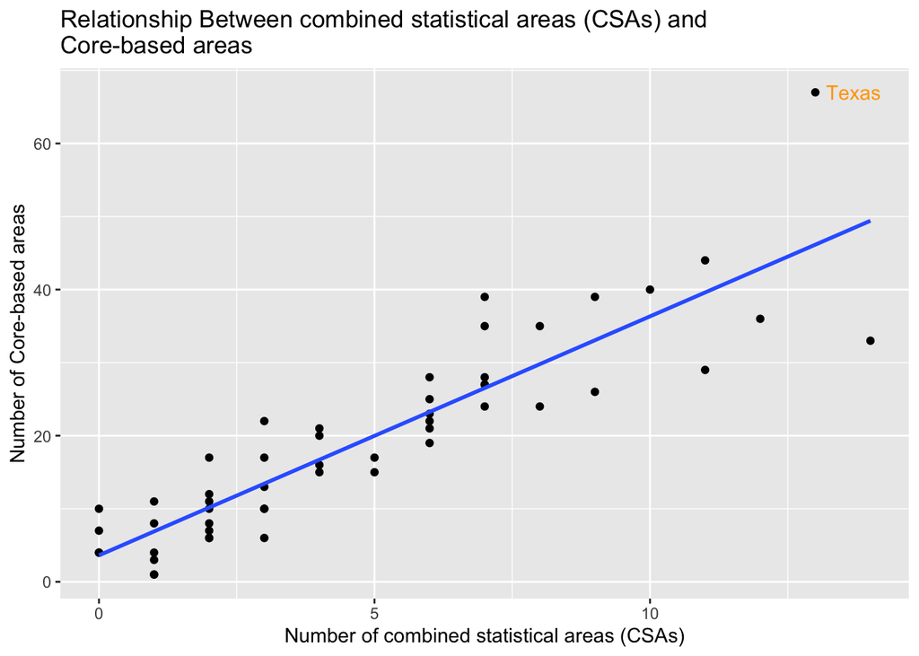

```r
ggplot(wiki_df, aes(x = `CSAs`, y = `Core-based areas`)) +
  geom_point() +
  geom_smooth(method = "lm", se = FALSE) +
  labs(title = "Relationship Between combined statistical areas (CSAs) and\nCore-based areas",
       x = "Number of combined statistical areas (CSAs)",
       y = "Number of Core-based areas") +
  geom_text(data = subset(wiki_df, Jurisdiction == "Texas"),
            aes(label = Jurisdiction),
            hjust = -0.2,
            color = "orange")
```

6. Interpret the plot and answer your question.

From the graph, it can be seen that there is a strong positive linear relationship between combined statistical areas (CSAs) and core-based areas (CBAs). Additionally, it is worth noting that Texas has a particularly high ratio of CBAs to CSAs, which may indicate that the state faces challenges in overall economic development and regional planning. This situation necessitates greater attention to cross-regional cooperation and integration to promote economic growth and resource sharing.

It is easiest if the site is a static site for the data of interest and does not depend upon you clicking on the page to expose the data. However, those are getting rarer. If it is a site that is dynamic, but you can scrape the first page that loads, that is fine as long as you can produce a reasonable plot.